# Quantile Normalization — Step-by-step Demo

Mikhail

2025-09-23

# 1 Overview

This document demonstrates quantile normalization on RNA-seq–like data. Steps:

1. simulate count data with library-size and composition differences
2. convert to log2(CPM + 1) (common starting point for applying quantile normalization)
3. visualize raw distributions (boxplots, density)
4. implement **manual quantile normalization** (showing the core algorithm)
5. visualize normalized data and compare to `limma::normalizeBetweenArrays(method="quantile")`

# 2 Load packages

```r
# Install packages if needed (uncomment to install)
# install.packages(c("ggplot2","reshape2","pheatmap"))
# if (!requireNamespace("BiocManager", quietly=TRUE)) install.packages("BiocManager")
# BiocManager::install("limma")

library(ggplot2)
library(reshape2)
library(limma)     # for normalizeBetweenArrays (quantile)
library(pheatmap)
```

# 3 Simulate RNA-seq like counts

We simulate 1,000 genes and 6 samples. We include differing library sizes and a compositional bias in one sample to mimic real-world distributional differences.

```r
set.seed(42)
G <- 1000   # genes
S <- 6      # samples

# baseline gene expression means (per-gene)
base_means <- rgamma(G, shape = 2, scale = 50)  # varying baseline abundances

# sample-specific library size factors
libsize_factors <- c(1.0, 0.9, 1.2, 1.1, 0.8, 1.5)

# create matrix of counts using NB (mu scaled by libsize)
dispersion <- 10  # NB size parameter (higher => lower overdispersion)
counts <- matrix(0, nrow=G, ncol=S)
for (s in seq_len(S)) {
  mu_s <- base_means * libsize_factors[s]
  counts[,s] <- rnbinom(G, mu = mu_s, size = dispersion)
}

colnames(counts) <- paste0("Sample", 1:S)
rownames(counts) <- paste0("Gene", seq_len(G))

# introduce compositional bias: in sample 6, amplify a small set of genes
set.seed(3)
highly_expressed <- sample(1:G, 25)
counts[highly_expressed, 6] <- counts[highly_expressed, 6] * 20

# quick summary
library_sizes <- colSums(counts)
round(library_sizes / 1e6, 4)  # in millions
```

```
## Sample1 Sample2 Sample3 Sample4 Sample5 Sample6
##  0.0949  0.0864  0.1162  0.1067  0.0768  0.2233
```

# 4 Convert counts → CPM → log2(CPM + 1)

Quantile normalization is typically applied to continuous intensity-like data (e.g., log2 scale). We’ll compute counts per million (CPM) then log2(CPM + 1).

```r
# compute CPM
cpm <- sweep(counts, 2, colSums(counts), FUN="/") * 1e6
log2cpm <- log2(cpm + 1)

# show head
head(log2cpm)[,1:6]
```

```
##         Sample1   Sample2   Sample3   Sample4   Sample5   Sample6
## Gene1 10.702186 11.025404 11.735172 11.332013 11.146386 10.230126
## Gene2  9.015040  7.997945  9.411294  9.063754  9.537639  8.395943
## Gene3  9.774227  8.784062  8.752597  9.515540  9.486179  8.625923
## Gene4  8.046861  7.540628  7.115832  7.627795  8.231177  7.419216
## Gene5  9.399677  9.643188  9.677012  9.639366  9.971031  9.011124
## Gene6  8.401811  7.861005  8.863381  7.145283  8.660572  7.341682
```

# 5 Visualize raw (log2CPM) distributions

Boxplots and density plots to visualize per-sample distributional differences.

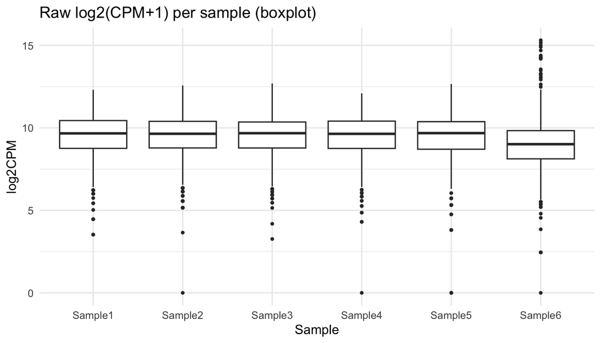

```r
df_raw <- melt(log2cpm)
colnames(df_raw) <- c("Gene", "Sample", "log2CPM")

# boxplot
p1 <- ggplot(df_raw, aes(x=Sample, y=log2CPM)) +
  geom_boxplot(outlier.size = 0.8) + ggtitle("Raw log2(CPM+1) per sample (boxplot)") +
  theme_minimal()
p1
```

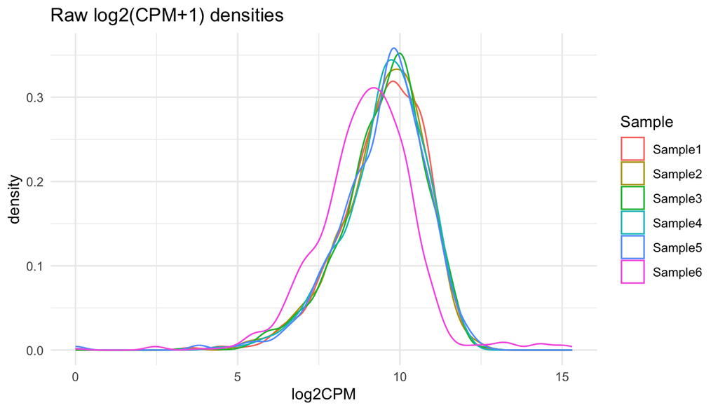

```r
# density
p2 <- ggplot(df_raw, aes(x=log2CPM, color=Sample)) +
  geom_density() + ggtitle("Raw log2(CPM+1) densities") + theme_minimal()
p2
```

*Interpretation:* note sample-to-sample distribution differences (library size & composition effects), particularly the sample with amplified genes.

# 6 Manual implementation of Quantile Normalization

Algorithm (conceptual):

1. For each sample (column) sort values in ascending order.
2. Compute the row-wise mean across the sorted columns (this gives the target quantiles).
3. For each column, replace its sorted values by the target quantile means, and then undo the sorting to restore original ordering.

Below is a straightforward implementation and demonstration.

```r
quantile_normalize_manual <- function(mat) {
  # mat: numeric matrix with genes as rows and samples as columns
  stopifnot(is.matrix(mat))
  # 1) sort each column
  sorted_mat <- apply(mat, 2, sort, decreasing = FALSE)
  # 2) row means across sorted values (target quantiles)
  target_quantiles <- rowMeans(sorted_mat, na.rm = TRUE)
  # 3) map target quantiles back to original ranks
  result <- mat * NA
  for (j in seq_len(ncol(mat))) {
    ord <- order(mat[, j], na.last = NA)         # indices of sorted values ascending
    result[ord, j] <- target_quantiles
  }
  return(result)
}

# apply manual quantile normalization
log2cpm_qn_manual <- quantile_normalize_manual(log2cpm)
```

# 7 Visualize manual quantile-normalized data

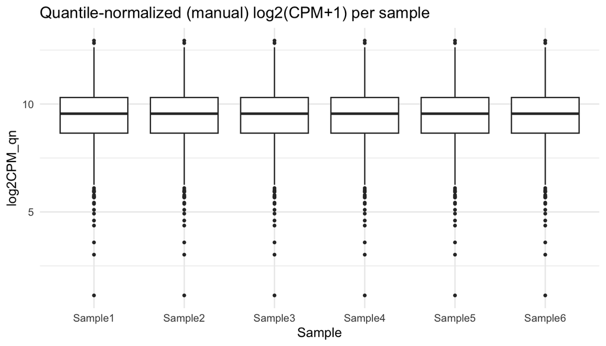

```r
df_qn <- melt(log2cpm_qn_manual)
colnames(df_qn) <- c("Gene", "Sample", "log2CPM_qn")

# boxplot after QN
p3 <- ggplot(df_qn, aes(x=Sample, y=log2CPM_qn)) +
  geom_boxplot(outlier.size = 0.8) + ggtitle("Quantile-normalized (manual) log2(CPM+1) per sample") +
  theme_minimal()
p3
```

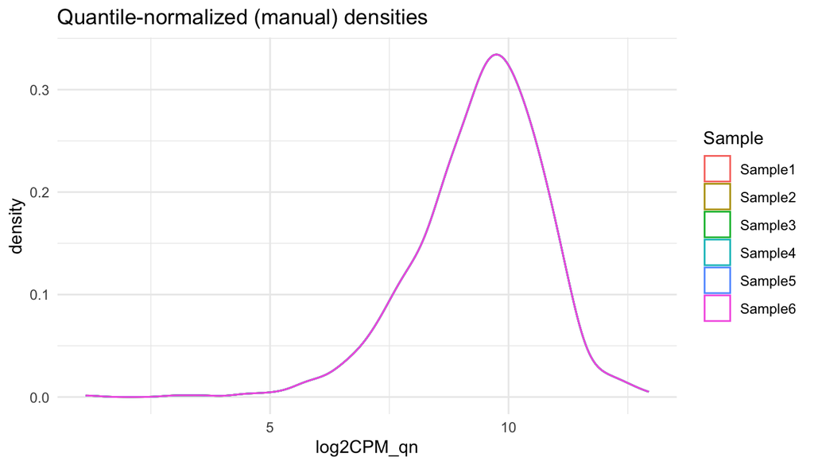

```r
# density after QN
p4 <- ggplot(df_qn, aes(x=log2CPM_qn, color=Sample)) +
  geom_density() + ggtitle("Quantile-normalized (manual) densities") + theme_minimal()
p4
```

*Interpretation:* after quantile normalization, per-sample marginal distributions are identical (by construction). This can remove unwanted technical differences but also may remove true global biological differences.

# 8 Compare with limma’s quantile normalization

We use `limma::normalizeBetweenArrays()` which implements a standard quantile normalization.

```r
log2cpm_qn_limma <- normalizeBetweenArrays(log2cpm, method = "quantile")

# check equality up to numerical tolerance
max_abs_diff <- max(abs(log2cpm_qn_manual - log2cpm_qn_limma))
max_abs_diff
```

```
## [1] 1.888681
```

[figure not shown]

```r
df_qn <- melt(log2cpm_qn_limma)
colnames(df_qn) <- c("Gene", "Sample", "log2CPM_qn")

# boxplot after QN
p3 <- ggplot(df_qn, aes(x=Sample, y=log2CPM_qn)) +
  geom_boxplot(outlier.size = 0.8) + ggtitle("Quantile-normalized (manual) log2(CPM+1) per sample") +
  theme_minimal()
p3
```

[figure not shown]

```r
# density after QN
p4 <- ggplot(df_qn, aes(x=log2CPM_qn, color=Sample)) +
  geom_density() + ggtitle("Quantile-normalized (manual) densities") + theme_minimal()
p4
```